# Global Management of Antimicrobial Resistance

97039 - GLOBAL HEALTH, ANTIMICROBIAL DRUGS AND VACCINES

Russell E. Lewis, Associate Professor, Infectious Diseases

11/1/2022

## Overview

Until the 20th Century, influenza, pneumonia, tuberculosis, and diarrhea/enteric diseases were the top three causes of death in Western countries. The average life expectancy of adults was less than 50 years, and 2% of children failed to live beyond age 5 years.

Industrialization and growing wealth in the 19th century brought improvements in sanitation and drinking water, leading to dramatic reductions in communicable enteric infections. By the early 20th century, vaccines for pertussis, tuberculosis, diptheria and yellow fever were being developed and tested in clinical trials. However, life-threating bacterial infections remained a common threat. Strep throat was sometimes a fatal disease, ear infections could lead deafness, mastoiditis or meningitis with a 90% mortality rate, and surgery or childbirth was much more dangerous.

[interactive chart not shown]

The microbiologist and immunologist Paul Ehrlich (1854-1915) is generally credited with the first discovery of an antibiotic for the medical treatment of syphilis-arsphenamine or Salvarsan. The term “antibiotic” was later introduced by in 1943 by Selman Waksman-the discoverer of streptomycin. Erlich’s approach of screening synthetic libraries of chemicals for selective antimicrobial properties was the basis of early antibiotic research and led to the discovery of the first sulfa antibiotics (e.g., sulfamidochrysoidine, sulfanilamide).

However, it was the serendipitous discovery of penicillin on September 3, 1928 by Alexander Fleming and the subsequent purification of the drug in quantities needed for clinical testing by Florey and Chain in the late 1930s eventually led to mass production and distribution of penicillin by 1945- ushering in the modern antibiotic age. Alexander Fleming was also among the first to cautioned about the potential resistance to penicillin if used too little or for a too short of period during treatment.

> It is not difficult to make microbes resistant to penicillin in the laboratory by exposing them to concentrations not sufficient to kill them, and the same thing has occasionally happened in the body. The time may come when penicillin can be bought by anyone in the shops. Then there is the danger that the ignorant man may easily under-dose himself and by exposing his microbes to non-lethal quantities of the drug make them resistant. -Sir Alexander Fleming

Indeed, Fleming’s predictions were proven to be true within a couple of years, with the first case of penicillin resistance reported in 1947. Thus began an “arms race” between discovery or novel antibiotics and antimicrobial resistance.

Although resistant infections were frequently encountered in the early days of antibiotic use, a flow of new antibiotics from 1950s-1980’s provided alternative treatments. It was possible to simply switch treatment once resistance against a specific antibiotic became a major problem. But then the antibiotic discovery began to slow. The latest discovery of a new antibiotic class that has reached the market was in 1987. Since then, there has been a lack of innovation in the field, and today there are few novel antibiotic classes in the drug pipeline. In Module 2 we will scientific and market forces that have made new antibiotic discovery increasing difficult in both in both developed and low-middle-income countries (LMICs)

Once a resistant bacterium has developed, it can spread from a colonised person to another person if appropriate hygienic precautions (e.g., hand hygiene, isolation) are not taken. The risk of resistant bacteria spreading is enhanced in crowded environments, especially when people in the surrounding area are receiving antibiotics - a common situation in hospitals and other healthcare facilities.

The consequences of faltering antibiotic discovery are now seen worldwide as more and more bacterial infections are becoming hard to treat once again. Especially worrisome is the lack of antibiotics against Gram-negative bacteria. The rapid global spread of multi- and pan-resistant bacteria (also known in the lay press as “superbugs”) can cause infections that are not treatable with existing antibiotics.

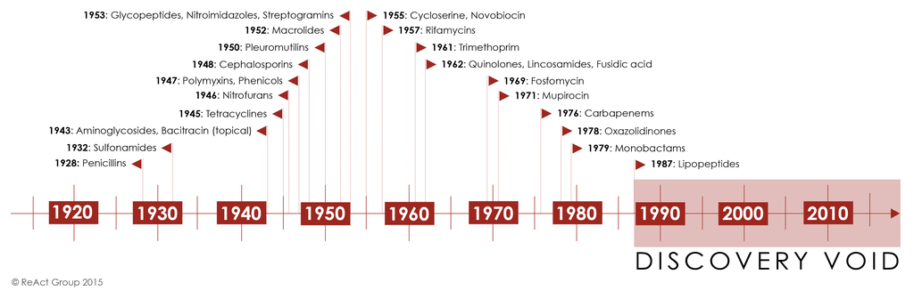

Figure 1. Antibiotic discovery timeline

## Current situation

Recognizing the growing global threat of antibiotic resistance (AMR) on human health but also the economy and human development, The World Health Organization (WHO) in 2017 developed a [Global Action Plan on AMR](https://www.who.int/publications/i/item/9789241509763). The global health plan outlines 21 strategies and 5 strategic objectives of a national action plans to addressing AMR.

1. Improve awareness and understanding of antimicrobial resistance through effective communication, education and training
2. Strengthen the knowledge and evidence base through surveillance and research
3. Reduce the incidence of infection through effective sanitation, hygiene and infection prevention measures
4. Optimize the use of antimicrobial medicines in human and animal health
5. Develop the economic case for sustainable investment that takes account of the needs of all countries, and increase investment in new medicines, diagnostic tools, vaccines and other interventions

The WHO also published a [Priority Pathogen List](https://www.who.int/medicines/publications/WHO-PPL-Short_Summary_25Feb-ET_NM_WHO.pdf) for research and development of new antibiotics. This list is in addition to M*ycobacteria* (including *Mycobacterium tuberculosis,* the cause of human tuberculosis), which was globally established priority for which innovative new treatments are urgently needed The list breaks down pathogens into three priority groups:

Table 1. WHO antibiotic resistance priority pathogens list

| Priority group | Pathogens included |
| --- | --- |
| Critical | *Acinetobacter baumannii* (Carbapenem-resistant) *Pseudomonas aeruginosa* (Carbapenem-resistant) Enterbacterales (3rd generation cephalosporin, carbapenem-resistant) |
| High | *Enterococcus faecium*, vancomycin-resistant *Staphylococcus aureus*, methicillin-resistant, vancomycin intermediate and resistant *Helicobacter pylori*, clarithromycin-resistant *Campylobacter*, fluo… |
| Medium | *Streptococcus pneumoniae*, penicillin-non-susceptible *Haemophilus influenzae*, ampicillin-resistant *Shigella* spp., fluoroquinolone-resistant |

## Situation in Italy

- 26.4% of *Escherichia coli* are resistant to 3rd generation cephalosporins
- 29.5% of *Klebsiella pneumoniae* are resistant to carbapenems (including 33.1% resistant to multiple drug classes)
- 15.9% of *Pseudomonas aeruginosa* are resistant to carbapenemase
- 80.8% of *Acinetobacter* spp. are resistant to carbapenems with 78.8% of species resistant to multiple drug classes
- For *Staphylococcus aureus* , the percentage of methicillin-resistant isolates (MRSA) remained stable, around 34%, while a worrying trend continues to increase in the percentage of *Enterococcus faecium isolates* resistant to vancomycin, which in 2020 was equal at 23.6%
- For *Streptococcus pneumoniae* there was a slight increase in both the percentage of isolates resistant to penicillin (13.6%) and those resistant to erythromycin (24.5%).
- Higher resistance rates (around 40%) were observed in ICUs than in other wards for both carbapenem-resistant *K. pneumoniae* and methicillin-resistant *S. aureus*.

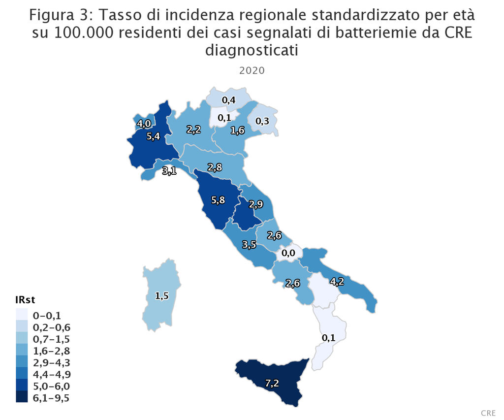

Figure 2. Regional difference in CRE bloodstream infection incidence per 100,000 residents in Italy. Source:Micronet https://www.epicentro.iss.it/antibiotico-resistenza/cre-dati

In 2017, a [report](https://www.ecdc.europa.eu/en/publications-data/ecdc-country-visit-italy-discuss-antimicrobial-resistance-issues) by the the ECDC noted that:

> Observations from this ECDC country visit confirm that the AMR situation in Italian hospitals and regions poses a major public health threat to the country. The levels of carbapenem-resistant Enterobacteriaceae (Enterobacterales) (CRE) and *Acinetobacter baumannii* have now reached hyper-endemic levels and, together with methicillin-resistant *Staphylococcus aureus* (MRSA), this situation causes Italy to be one of the Member States with the highest level of resistance in Europe. During conversations in Italy, ECDC often gained the impression that these high levels of AMR appear to be accepted by stakeholders throughout the healthcare system, as if they were an unavoidable state of affairs. The factors that contribute negatively to this situation seem to be:
> - Little sense of urgency about the current AMR situation from most stakeholders and a tendency by many stakeholders to avoid taking charge of the problem
> - Lack of institutional support at national, regional and local level
> - Lack of professional leadership at each level
> - Lack of accountability at each level
> - Lack of coordination of the activities between and within levels.

## How will medicine change in the next 20 years if antimicrobial resistance cannot be better addressed?

- Drug-resistant diseases already cause at least 700,000 deaths globally a year, including 230,000 deaths from multidrug-resistant tuberculosis, a figure that could increase to 10 million deaths globally per year by 2050 under the most alarming scenario if no action is taken. Around 2.4 million people could die in highincome countries between 2015 and 2050 without a sustained effort to contain antimicrobial resistance.
- Many common infections will not be treatable. Routine medical procedures or surgery become much more dangerous. Lifesaving Immunosuppression, cancer chemotherapy and transplantations may become associated with unacceptable risk to the patient
- Economic and social progress in many countries will be dramatically impacted threatening to reverse a century of progress. The economic damage of uncontrolled antimicrobial resistance could be comparable to the shocks experienced during the 2008-2009 global financial crisis as a result of dramatically increased health care expenditures; impact on food and feed production, trade and livelihoods; and increased poverty and inequality. The impact in LMIC will be even greater and longer lasting

## One-Health Perspective

Because the drivers of antimicrobial resistance lie in humans, animals, plants, food and the environment, a sustained One Health response is essential to engage and unite everyone around a shared vision and goals.

“One Health” refers to designing and implementing programmes, policies, legislation and research in a way that enables multiple sectors engaged in human, terrestrial and aquatic animal and plant health, food and feed production and the environment to communicate and work together to achieve better public health outcomes.

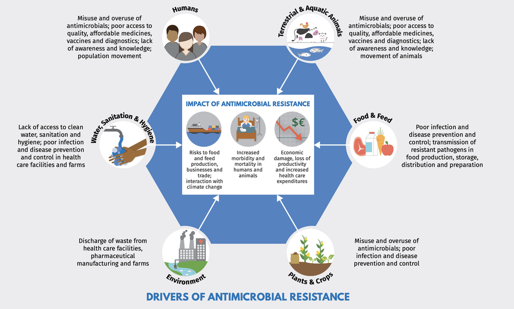

Figure 3. A One Health response to address the drivers and impact of antimicrobial resistance. From https://www.who.int/docs/default-source/documents/no-time-to-wait-securing-the-future-from-drug-resistant-infections-en.pdfsfvrsn=5b424d7_6

## Low-Middle Income Countries

## Cross-Boarder Spread of Resistance

[European air traffic visualization] (https://https://vimeo.com/88093956)

## Simulation Exercise on Microsoft Teams